# Exploratory Data Analysis

```r
cor(pitcher_data$xwoba, pitcher_data$`ERA (t+1)`)
```

```
## [1] 0.3088845
```

Already, we see that the more advanced analytics have stronger correlations with future ERA than the more rudimentary counting statistics. Additionally, we see that expected weighted on-base average (xwOBA) outperforms weighted on-base average (wOBA). Unlike wOBA, xwOBA attempts to mitigate some of the stochasticity in pitching outcomes by aggregating batted ball data to predict results. In some ways, we can think of xwOBA has a more true measure of pure pitching performance than wOBA, which helps explain why it has a stronger correlation with future ERA. This also allows us to explore the difference between outcome-based statistics (like wOBA) and estimates of expected outcome (like xwOBA) as a measure of a pitcher's "luck", that is how much better or worse batters performed against the pitcher than expected (based on the quality of caontact allowed). A further extension of comparing the differences in outcome and expected outcome is to determine if those differences tend to correct themselves over time. To do so, we analyze the change in a pitcher's ERA from one season to the next as explained by the difference between different predictive and raw measures:

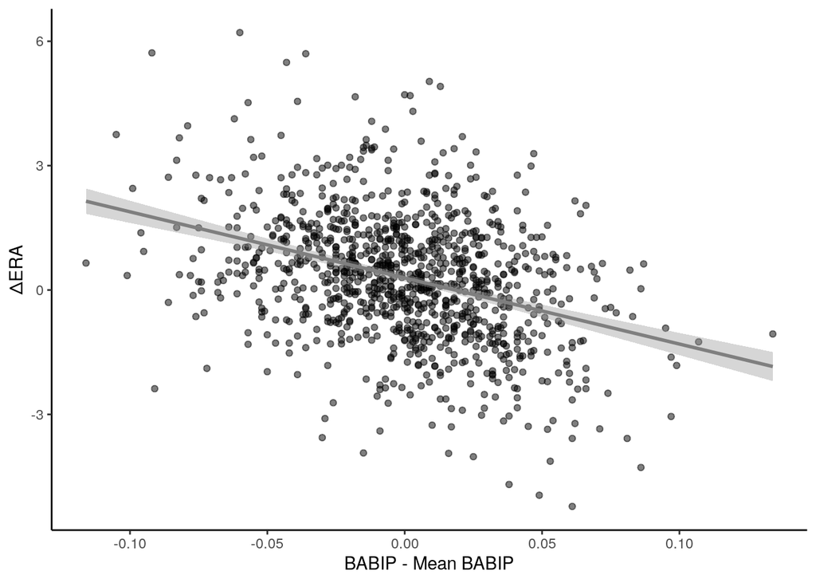

```r
pitcher_data %>%
  ggplot(aes(x = `BABIP - Mean BABIP`, y = `ΔERA`)) +
  geom_point(alpha = 0.5) +
  geom_smooth(method = lm, color = "grey50") +
  theme_classic()
```

```r
cor(pitcher_data$`BABIP - Mean BABIP`, pitcher_data$`ΔERA`)
```

```
## [1] -0.355732
```

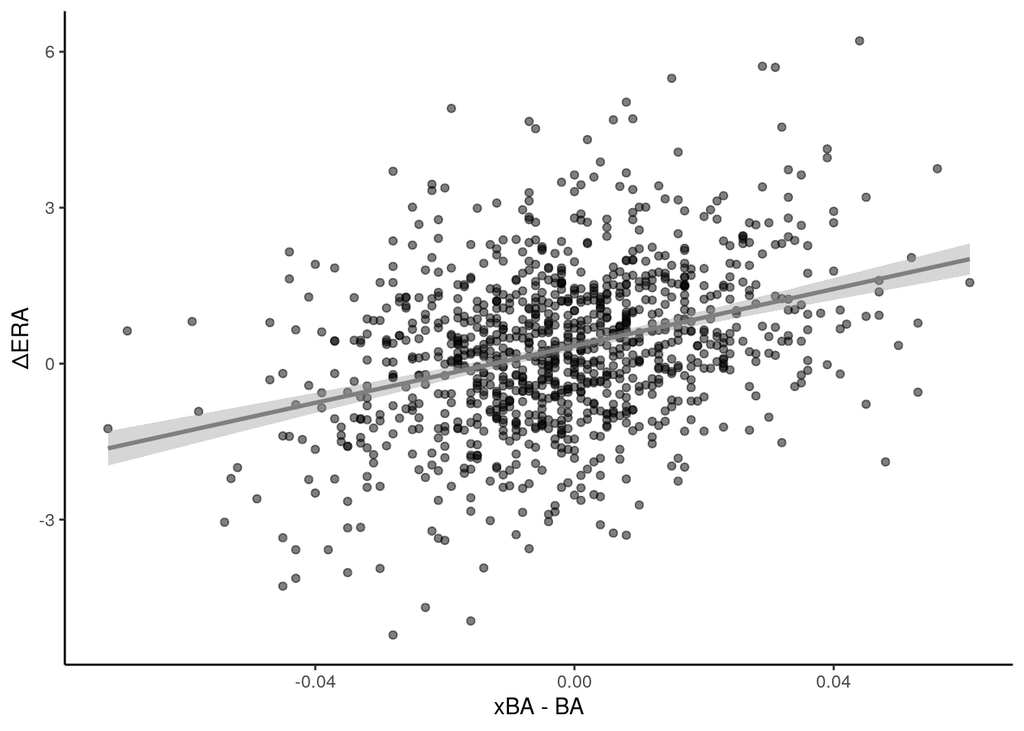

```r
pitcher_data %>%
  ggplot(aes(x = `xBA - BA`, y = `ΔERA`)) +
  geom_point(alpha = 0.5) +
  geom_smooth(method = lm, color = "grey50") +
  theme_classic()
```

```r
cor(pitcher_data$`xBA - BA`, pitcher_data$`ΔERA`)
```

```
## [1] 0.3409661
```

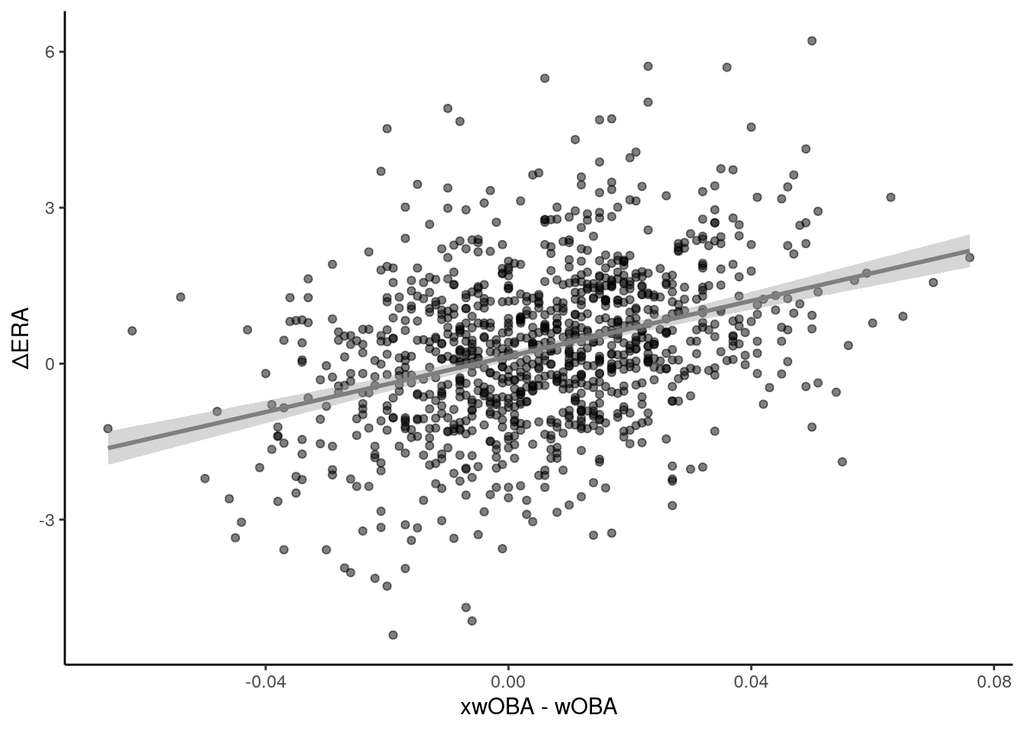

```r
pitcher_data %>%
  ggplot(aes(x = `xwOBA - wOBA`, y = `ΔERA`)) +
  geom_point(alpha = 0.5) +
  geom_smooth(method = lm, color = "grey50") +
  theme_classic()
```

```r
cor(pitcher_data$`xwOBA - wOBA`, pitcher_data$`ΔERA`)
```

```
## [1] 0.3502287
```

As we see in the data, there is clear statistical evidence of what we could call "mean-reversion of luck". Pitchers whose actual performances were worse than expected performances generally saw an increase in ERA the next season as there "luck" reverted closer to the mean. The opposite can be said for Pitchers who performed better than exoected. This conclusion suggests that including differences in outcome-based statistics and expected statistics should significant improve the predictive power of our model.

# Conclusion

From our preliminary data exploration, it appears that discrepancies exist between the predictors that are associated with salary and the predictors associated with future performance. Specifically, it seems like raw, unadjusted counting stats associated with volume of pitches rather than quality are highly correlated with salary; while advanced statistics, especially statistics that calculate expected values, are better predictors of future performance. We also elucidated the phenomenon of a "mean-reversion of luck" which suggests that a pitcher's expected performance, derived from statistics such as xWOBA and xBA rather than just WOBA and BA, can help remove some of the noise associated with luck and stochastic fluctuations. Overall, it appears that the differences in strength of correlation between salary and future performance are significant, our next step will be to create and fine-tune models to predict both response variables to both futher delineate what predictors the models differ on as well as investigate both over- and under-paid or valued pitchers.